# Naturindeks plankton innsjøer (PTI)

Kristina Øie Kvile, NIVA

14 februar 2025

Dette dokumentet går gjennom arbeidsflyten i R for å kjøre statistiske analyser og predikere NEQR-verdier for alle kommuner og ønskede år, for de indikatorene NIVA skal levere til Naturindeksen. De predikserte NEQR-verdiene blir lastet opp til NI-databasen ved hjelp av biblioteket NICalc i scriptet [NICalc_upload](https://github.com/NIVANorge/naturindeks/blob/main/analyser/NICalc_upload.r). Dette R markdown-dokumentet kan kjøres i løkke for flere variabler i scriptet [analyses_neqr](https://github.com/NIVANorge/naturindeks/blob/main/analyser/analyses_neqr.r).

# Databehandling

Først laster vi inn data for en indikatoren som skal analyseres, konvertert fra rådata til nEQR-verdier i scriptet convert2neqr.r. Vi laster også inn datasett med oversikt over alle kommuner, vannforekomster, økoregioner og vanntyper, for det relevante habitatet til den gitte indikatoren.

```
## [1] "Indikator: Naturindeks plankton innsjøer (PTI)"
```

```
## [1] "Fil med nEQR-verdier (ForcingData): ../../01_Data/03_NEQR/NEQR_PTI.xlsx"
```

```
## [1] "Habitat: innsjo"
```

[output not shown]

```
## [1] "PredData: ../../01_Data/02_Vannforekomster/Naturindeks-innsjo.xlsx"
```

Observasjoner per år i ForcingData:

| Year | n |
| --- | --- |
| 1988 | 3 |
| 2001 | 1 |
| 2005 | 7 |
| 2006 | 1 |
| 2007 | 5 |
| 2008 | 5 |
| 2009 | 1 |
| 2010 | 10 |
| 2011 | 18 |
| 2012 | 20 |
| 2013 | 44 |
| 2014 | 68 |
| 2015 | 56 |
| 2016 | 55 |
| 2017 | 62 |
| 2018 | 72 |
| 2019 | 4 |
| 2020 | 77 |
| 2021 | 53 |
| 2022 | 71 |
| 2023 | 68 |
| 2024 | 2 |

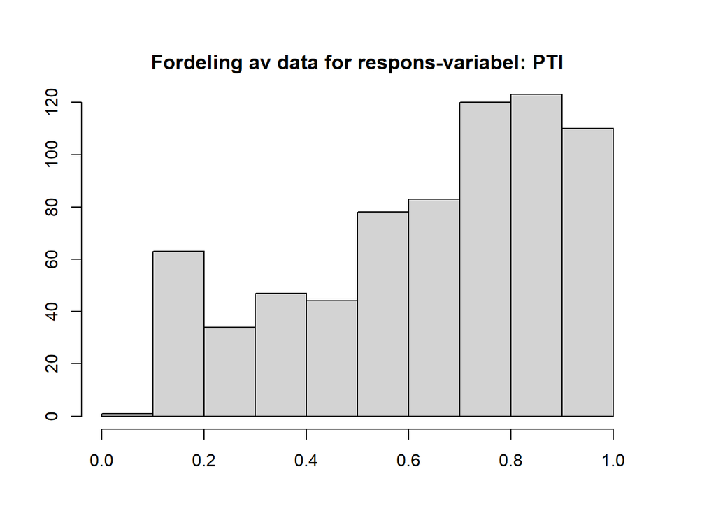

Vi klargjør datasettet for modelleringen ved å:  
1. Splitte “vanntype” i sine delkomponenter (“typologifaktorer”)  
2. Slå sammen de to nordlige økoregionene for ferskvann

Dette gjøres for både ForcingDataog og PredData.

For oversikt over typologifaktorer se [Klassifiseringsveileder 02:2018](https://www.vannportalen.no/veiledere/klassifiseringsveileder).

```
##
##
## Table: Observasjoner per økoregion i ForcingData:
##
## |Okoregion | Ant. Vanntyper| Ant. obs|
## |:---------|--------------:|--------:|
## |E         |             49|      455|
## |M         |             16|       38|
## |N         |             14|       32|
## |S         |             16|       43|
## |W         |             26|      135|
##
##
##
## Table: Observasjoner per økoregion i PredData:
##
## |Okoregion | Ant. Vanntyper| Ant. obs|
## |:---------|--------------:|--------:|
## |E         |            137|     1371|
## |M         |            147|     1390|
## |N         |            140|     1746|
## |S         |            135|      941|
## |W         |            128|     1765|
```

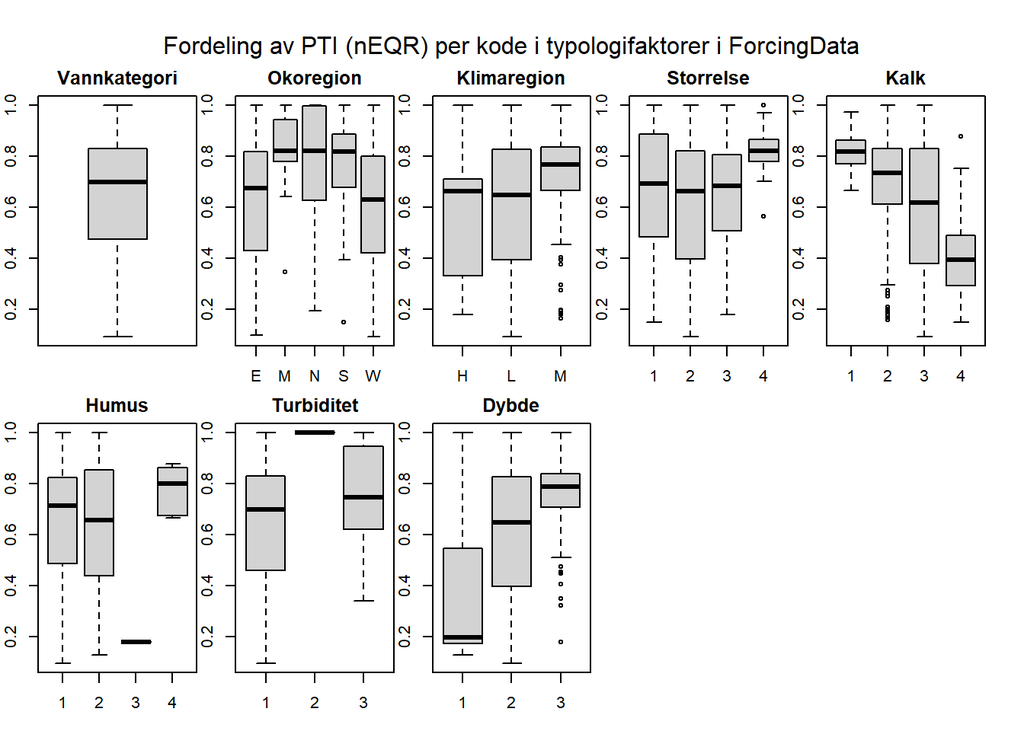